# Measuring Migration with ACS Flow Estimates

One question on an American survey form, the map it draws, and how much of that map is not there

Democracy’s Data

Last updated September 13, 2026 at 10:53a EDT

Every few months a headline announces that Americans are fleeing one state for another. Fleeing California for Texas, fleeing New York for Florida, fleeing taxes, rents, and each other. The claim arrives with maps full of confident arrows. Is it true? Who actually moves, between which states, and how would anyone know?

The United States does not record moves. No government register learns your address when you change it. What stands in its place is a single question on the American Community Survey: **Where did you live one year ago?** Cross the answers against where each household lives now, weight the sample up so that it adds to the whole population, and out comes a 52 × 52 table — 2,652 ordered pairs of places, a number printed in every cell.

One of those cells is Minnesota to Utah. It reads 2,617 ± 3,046. The second number is the Bureau’s published 90 percent margin of error: how far off the estimate could be and still be doing its job, set so that nine times in ten the true figure lies within that distance of the estimate.[^1] Read the two together and the federal government is saying that the number of people who made that move was somewhere between nobody at all and about 5,663. **The estimate is smaller than its own uncertainty.** Every figure in this brief carries a margin like that, and almost none of them is ever printed with it.

## The test

The test is the Census Bureau’s own flow table: *State-to-State Migration Flows* from the 2024 American Community Survey one-year estimates, downloadable from the address in the sources below; the copy read here is from 10 August 2026. For the long view it is joined by the [Current Population Survey](https://www.census.gov/data/tables/time-series/demo/geographic-mobility/historic.html), the Bureau’s monthly household survey best known for producing the unemployment rate, which has asked the same question every year since 1948. The ACS is a survey, and the American Community Survey chapter is its biography: roughly 3.5 million addresses a year, weighted up to the country, a margin of error published beside every estimate.

It is the right source because there is no better one, and the near misses are instructive. The [Internal Revenue Service](https://www.irs.gov/statistics/soi-tax-stats-migration-data) builds county-to-county migration from the addresses on consecutive tax returns, an administrative record with no margin of error at all. But it covers only tax filers and the people claimed on their returns, which leaves out the poor and the young, and they are the most mobile people in the country. The Postal Service knows every forwarding order and publishes no flow table. A survey with honest margins is what remains, and the margins turn out to be the story.

## The data

The workbook the Bureau publishes was built to be looked at, not computed with. Its first eight rows are headers, one of which explains in a sentence where the headers are. Column names arrive with footnote markers welded on, so `Residence 1 year ago2` is a name carrying a footnote. And every state-to-itself cell holds the letter `X` in a numeric column: people who did not leave their state are suppressed, not counted.

The table handed over below, `flows.csv`, reshapes that workbook into one row per ordered pair of states. Its columns are `from_state`, `to_state`, the estimate `est`, its margin `moe`, the interval ends `lo` and `hi`, and a flag `sig`. Here is the top of it:

| From | To | Estimate | Margin | Low | High | Differs from zero |
| --- | --- | --- | --- | --- | --- | --- |
| Alaska | Alabama | 387 | 404 | 0 | 791 | FALSE |
| Arizona | Alabama | 2055 | 1402 | 653 | 3457 | TRUE |
| Arkansas | Alabama | 958 | 757 | 201 | 1715 | TRUE |

| Stage | Rows |
| --- | --- |
| Ordered pairs of states | 2652 |
| Pairs carrying an estimate | 2373 |
| Pairs suppressed or blank | 279 |

Three cleaning decisions sit in those columns, and each is a judgment. The `X` cells were read as absence rather than zero: 279 of the 2,652 pairs carry no usable estimate, and turning them into zeros would assert that nobody made those moves. The interval ends are the estimate plus and minus its margin, with the bottom held at zero, because a negative number of movers is not a thing. That clamp quietly makes some intervals lopsided. And `sig` is this brief’s arithmetic, not the Bureau’s: it asks only whether the interval clears zero.

Two companion tables travel with the flows. `states.csv` has one row per state: arrivals `in_est`, departures `out_est`, the difference `net`, each with its margin, plus `born_state_pct`, the share of residents born in the state they live in. `mobility.csv` is the Current Population Survey series: for each year since 1948, the share of Americans who moved at all (`movers`) and the share who crossed a state line (`diff_state`).

Before any arrows are drawn, the proportions:

| Quantity | People |
| --- | --- |
| Moved within their own state | 29,888,154 |
| Moved to a different state | 7,157,607 |
| Moved to the U.S. from abroad | 2,552,193 |
| Population 1 year and over | 336,636,468 |

29,888,154 people moved inside their own state against 7,157,607 who crossed a state line. The interstate migration everyone argues about is roughly 19% of domestic moving, and about 2.1% of the population in a year. The flows are real, and they are small beside the stayers.

> **Before you read on, commit to two numbers.** There are 2,652 ordered pairs of states in this table. **How many of them describe a flow the survey can tell apart from zero?** Write down a count, or a share of 2,652. Then a second number: **of all the people who moved between states that year, what share are in the pairs that fail?**

## What it says about democracy

Migration is apportionment, and apportionment is power. Every ten years the House of Representatives is redistributed by where people live: a state that gains people gains seats and electoral votes, and one that loses them loses both. Nobody votes on the transfer. It is settled by millions of private decisions about jobs, rent, and elderly parents, which is why this table gets argued over for the nine years between counts.

Start with the state with the biggest gap between arrivals and departures. The data picks it, not us: **California**.

| Quantity | Estimate |
| --- | --- |
| Moved INTO California from another state | 406,873 ± 16,100 |
| Moved OUT of California to another state | 661,205 ± 21,844 |
| Net (in minus out) | -254,332 ± 27,136 |
| Moved into California from abroad | 306,867 ± 16,022 |

**California lost 254,332 more people to other states than it gained from them**, the largest net domestic outflow of any state. That figure is larger than its own margin of error, so it is not a trick of the survey. The biggest gainers are Texas and Florida, up 72,680 and 67,630. Those loud claims stand; the trouble begins with the quiet ones.

**Direction:** arriving in California leaving California hide flows not distinguishable from zero

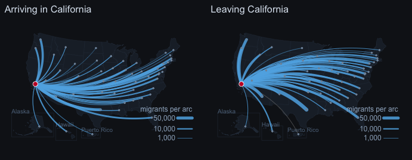

**Figure 1. Interstate migration into and out of California, drawn between population-weighted state centers, the point on which each state’s population would balance.** An arc map fits because the data is pairs of places: each arc is one pair, its width the number of people, on an absolute square-root scale keyed at lower right. Color carries a separate fact — blue means the estimate clears its own margin of error, gray means the survey cannot tell the flow apart from zero. In the browser the buttons switch direction; in print the two directions sit side by side.

The heaviest arc runs both ways, and it is the same arc. California and Texas exchange more people than any other pair of states in the country: 77,161 one way, 45,447 back. A net migration figure is a small difference between two very large numbers, which is exactly the situation where a margin of error matters most.

Now the prediction. The Bureau prints a margin beside every cell, so the test is arithmetic on the Bureau’s own two columns, applied to all 2,652 pairs:

| Outcome | Count |
| --- | --- |
| Ordered pairs of states in the table | 2,652 |
| Pairs the ACS will not report at all (flagged N) | 279 |
| Pairs reported as exactly zero | 276 |
| Pairs whose estimate is smaller than its own margin of error | 383 |
| Pairs that survive: a flow distinguishable from zero | 1,714 |
| Share of ALL interstate movers in the pairs that fail (%) | 2.21 |

Most readers write something in the nineties for the first number. It is 65%: **938 of the 2,652 pairs fail**, or 35% of the table. Having read that, most readers revise the second number upward, and it goes the other way. **The failed pairs hold 2.21% of the people who moved.** A margin of error is set, roughly, by how many sampled households made a given move, so it is close to a fixed amount. It wipes out thin flows and barely grazes thick ones: the middle surviving flow is 1,779 people, the middle failed one 129.

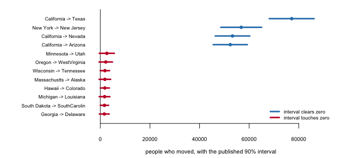

**Figure 2. Twelve flows with the 90 percent interval the Bureau publishes beside each one.** The top four are the largest flows in the country, where the interval is a rounding error beside the estimate. The eight below, in red, are the largest flows whose interval reaches zero: the survey cannot rule out that nobody at all made the move. The largest of them is Minnesota to Utah, at 2,617 ± 3,046.

So the table is wrong in a particular way, and it is not the way people usually fear. It is reliable about **volume**: nearly all interstate movement travels along flows large enough to measure. It is unreliable about **connections**, and the long, thin, surprising arc is precisely the one that makes a flow map look like a discovery. Nothing about the failing pairs is exotic. They are ordinary pairs of mostly small states, whose moves are rare in the sample rather than rare in the country. The pattern runs all the way up: for 22 of these 51 jurisdictions, even the statewide net migration figure cannot be told apart from zero.

One more exhibit reframes all of it. The Current Population Survey has asked the same question since 1948. It is a different survey with a different sample, so its levels do not belong on the ACS’s axis, but its direction is unambiguous.

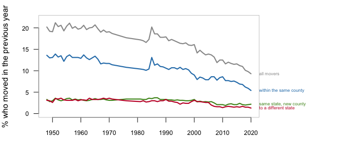

**Figure 3. The share of Americans who moved in the previous year, 1948 to 2020.** One line per kind of move, because the question is change over time. Every line falls: moving at all drops from 20.2% to 9.3%, and interstate moving from 3.1% to 1.3% — now 42% of its 1948 rate.

Every argument about Americans sorting themselves across the country is taking place against this decline. The flows are real. They are also small, shrinking, and at their edges unmeasurable.

## What this brief cannot tell you

**Why anybody moved.** There is no political column and no reason recorded anywhere in the file. The popular claim since Bishop’s *The Big Sort*, that Americans move toward politically like-minded places, cannot be tested here. The research that can test it finds the effect far weaker than advertised (Mummolo and Nall 2017).

**Who left the country.** The survey interviews only people living in the United States, so there is no matching figure for anyone who departed. Emigration in this data is not small and not zero; it is unmeasured. And “moved from abroad” is a statement about geography, not legal status: it mixes returning citizens, military families, students and immigrants, and separates nothing further.

**Anything finer than a state, reliably.** The county version of this table pools five years of sample (2016-2020), and even then only 338 of the 1,234 county flows into Los Angeles County clear their own margins. Finer grain means worse estimates.

**A trend, from the flow table alone.** It is a one-year snapshot: someone who moved in March and returned in November is invisible, and someone who moved three times counts once. The long decline in Figure 3 comes from a different instrument, trusted here for its direction and never for cell-by-cell comparison.

## What you should have learned

- One retrospective survey question is the entire national measurement of moving. In 2024, it found 7,157,607 people crossing state lines while 29,888,154 moved within their own state.
- 35% of the 2,652 state pairs fail their own published margins of error, but those pairs carry only 2.21% of the movers: the table is reliable about volume and unreliable about connections.
- The loud findings survive: California lost 254,332 people net, several times its margin, while Texas gained 72,680.
- The uncertainty sits exactly where the interesting-looking pattern is: the more specific a flow claim sounds, the more likely it is a product of sample size.
- Interstate moving has fallen to 42% of its 1948 rate, so whatever sorting is happening is happening while the mechanism slows.

## Extensions

- Every pair of states appears in `flows.csv` twice, once in each direction of `from_state` and `to_state`. Find a pair where the two directions are wildly unequal, and a pair where they almost cancel. What kind of state pair gives you each?
- Count the FALSE rows in the `sig` column of `flows.csv`, then look at which states they connect. Are the unusable pairs scattered, or concentrated on the small states?
- Sort `states.csv` by `born_state_pct`, then compare it with `net_per1k`. Are the states people are least likely to be born in also the states gaining the most people now?
- In `mobility.csv`, follow `diff_state` down the years and find the decade where the fall is steepest. Then go and read what else was happening then.
- **Stretch.** Download the previous year’s release of the same table from the Bureau’s server and rerun the margin test: do the same pairs fail, or does the set of failures churn from year to year?
- **Stretch.** The IRS publishes county-to-county migration built from tax returns, with no margins at all. Compare its picture of one state with this one, and work out which differences come from who each source can see.

## Sources

**Data**

- U.S. Census Bureau, *State-to-State Migration Flows*, 2024 American Community Survey 1-year estimates, Table T13. https://www2.census.gov/programs-surveys/demo/tables/geographic-mobility/2024/state-to-state-migration/State_to_State_Migration_Table_2024_T13.xlsx
- U.S. Census Bureau, *State of Residence by Place of Birth*, 2024 ACS 1-year estimates, Table T13. https://www2.census.gov/programs-surveys/demo/tables/geographic-mobility/2024/place-of-birth-acs-2024/State_of_Residence_By_Place_of_Birth_Table_2024_T13.xlsx
- U.S. Census Bureau, *County-to-County Migration Flows*, 2016-2020 ACS 5-year estimates. https://www2.census.gov/programs-surveys/demo/tables/geographic-mobility/2020/county-to-county-migration-2016-2020/county-to-county-migration-flows/county-to-county-2016-2020-ins-outs-nets-gross.xlsx
- U.S. Census Bureau, *Geographical Mobility*, CPS historical Table A-1, 1948 to 2020. https://www2.census.gov/programs-surveys/demo/tables/geographic-mobility/time-series/historic/tab-a-1.xls
- Internal Revenue Service, *SOI Tax Stats — Migration Data*, the county-to-county series built from tax returns that the text sets beside the survey. https://www.irs.gov/statistics/soi-tax-stats-migration-data
- U.S. Census Bureau, *Centers of Population by State*, 2020 Census; and *Cartographic Boundary Files*, 2020. https://www2.census.gov/geo/docs/reference/cenpop2020/CenPop2020_Mean_ST.txt and https://www2.census.gov/geo/tiger/GENZ2020/shp/cb_2020_us_state_20m.zip

Margins of error throughout are the Bureau’s published 90 percent margins.

**Academic literature**

- Bishop, Bill, with Robert G. Cushing (2008). *The Big Sort: Why the Clustering of Like-Minded America Is Tearing Us Apart.* Houghton Mifflin.
- Mummolo, Jonathan, and Clayton Nall (2017). “Why Partisans Do Not Sort: The Constraints on Political Segregation.” *The Journal of Politics* 79(1): 45–59.

**The data itself**

Every figure above is drawn from these tables. They are plain CSV, they open in a spreadsheet, and they are yours to take further.

`arcs.csv`, `county_focus.csv`, `flows.csv`, `map_insets.csv`, `map_states.csv`, `meta.csv`, `mobility.csv`, `states.csv`

Rebuild this data yourself, with an AI assistant

```
I want to rebuild a public dataset from its original sources, without
any starting files. Please do the following and show your work.

THE SOURCES. U.S. Census Bureau, all open, no account or key.
1. State-to-state migration flows from the American Community
   Survey, 2024 release, one spreadsheet of about 186 KB:
   https://www2.census.gov/programs-surveys/demo/tables/geographic-mobility/2024/state-to-state-migration/State_to_State_Migration_Table_2024_T13.xlsx
2. County-to-county flows, pooled over 2016-2020, one workbook of
   about 29 MB:
   https://www2.census.gov/programs-surveys/demo/tables/geographic-mobility/2020/county-to-county-migration-2016-2020/county-to-county-migration-flows/county-to-county-2016-2020-ins-outs-nets-gross.xlsx
3. The historical mover-rate series from the Current Population
   Survey, one old-format .xls of about 49 KB:
   https://www2.census.gov/programs-surveys/demo/tables/geographic-mobility/time-series/historic/tab-a-1.xls
And if you want to put any of it on a map: state population centers
at https://www2.census.gov/geo/docs/reference/cenpop2020/CenPop2020_Mean_ST.txt
and state outlines cb_2020_us_state_20m.zip under
https://www2.census.gov/geo/tiger/GENZ2020/shp/
These spreadsheets are laid out for reading, not parsing: multi-row
headers, margins of error interleaved beside estimates, footnotes at
the bottom. Expect to hunt for where the data starts.

WHAT TO BUILD.
1. Every ordered pair among the 50 states, DC and Puerto Rico: how
   many people moved from one to the other, with its margin of
   error, keeping count of the pairs the Bureau left blank.
2. The national picture from the same table: how many people moved
   between states that year.
3. The historical series: the share of Americans who moved in each
   year the survey asked, 1948 through 2020.

CHECK YOUR WORK. The copies this book used were downloaded in August
2026. If your rebuild matches them, you should find:
- 2,652 ordered pairs, of which 2,373 carry an estimate and 279 are
  blank
- 7,157,607 people moved between states
- 65 years in the mover series: about one American in five moved in
  1948 (20.2%), and 9.3% in 2019-2020
The migration tables are reissued with each ACS year, the county
workbook every five years; a later release holding different numbers
is a new measurement, not an error.
```

[^1]: U.S. Census Bureau, *Understanding and Using American Community Survey Data: What All Data Users Need to Know* (2020), on the 90 percent margins, https://www.census.gov/programs-surveys/acs/library/handbooks/general.html.